# Risk Factor Analysis

## Outcome Variable

**Outcome Variable:** wasted

## Predictor Variables

**Intervention Variable:** parity

**Adjustment Set:**

- arm
- W_mage
- meducyrs
- feducyrs
- hhwealth_quart
- W_mhtcm
- vagbrth
- W_nrooms
- impsan
- delta_W_mage
- delta_meducyrs
- delta_feducyrs
- delta_hhwealth_quart
- delta_W_mhtcm
- delta_vagbrth
- delta_W_nrooms
- delta_impsan

## Stratifying Variables

The analysis was stratified on these variable(s):

- agecat
- studyid
- country

## Data Summary

| agecat | studyid | country | parity | wasted | n_cell | n |
| --- | --- | --- | --- | --- | --- | --- |
| Birth | ki1000304b-SAS-CompFeed | INDIA | 1 | 0 | 37 | 166 |
| Birth | ki1000304b-SAS-CompFeed | INDIA | 1 | 1 | 4 | 166 |
| Birth | ki1000304b-SAS-CompFeed | INDIA | 2 | 0 | 41 | 166 |
| Birth | ki1000304b-SAS-CompFeed | INDIA | 2 | 1 | 3 | 166 |
| Birth | ki1000304b-SAS-CompFeed | INDIA | 3+ | 0 | 77 | 166 |
| Birth | ki1000304b-SAS-CompFeed | INDIA | 3+ | 1 | 4 | 166 |
| Birth | ki1101329-Keneba | GAMBIA | 1 | 0 | 139 | 1292 |
| Birth | ki1101329-Keneba | GAMBIA | 1 | 1 | 3 | 1292 |
| Birth | ki1101329-Keneba | GAMBIA | 2 | 0 | 131 | 1292 |
| Birth | ki1101329-Keneba | GAMBIA | 2 | 1 | 2 | 1292 |
| Birth | ki1101329-Keneba | GAMBIA | 3+ | 0 | 996 | 1292 |
| Birth | ki1101329-Keneba | GAMBIA | 3+ | 1 | 21 | 1292 |
| Birth | ki1126311-ZVITAMBO | ZIMBABWE | 1 | 0 | 4497 | 12915 |
| Birth | ki1126311-ZVITAMBO | ZIMBABWE | 1 | 1 | 1064 | 12915 |
| Birth | ki1126311-ZVITAMBO | ZIMBABWE | 2 | 0 | 3358 | 12915 |
| Birth | ki1126311-ZVITAMBO | ZIMBABWE | 2 | 1 | 524 | 12915 |
| Birth | ki1126311-ZVITAMBO | ZIMBABWE | 3+ | 0 | 3000 | 12915 |
| Birth | ki1126311-ZVITAMBO | ZIMBABWE | 3+ | 1 | 472 | 12915 |
| Birth | ki1135781-COHORTS | GUATEMALA | 1 | 0 | 66 | 756 |
| Birth | ki1135781-COHORTS | GUATEMALA | 1 | 1 | 28 | 756 |
| Birth | ki1135781-COHORTS | GUATEMALA | 2 | 0 | 87 | 756 |
| Birth | ki1135781-COHORTS | GUATEMALA | 2 | 1 | 31 | 756 |
| Birth | ki1135781-COHORTS | GUATEMALA | 3+ | 0 | 411 | 756 |
| Birth | ki1135781-COHORTS | GUATEMALA | 3+ | 1 | 133 | 756 |
| Birth | ki1135781-COHORTS | INDIA | 1 | 0 | 505 | 3855 |
| Birth | ki1135781-COHORTS | INDIA | 1 | 1 | 136 | 3855 |
| Birth | ki1135781-COHORTS | INDIA | 2 | 0 | 823 | 3855 |
| Birth | ki1135781-COHORTS | INDIA | 2 | 1 | 159 | 3855 |
| Birth | ki1135781-COHORTS | INDIA | 3+ | 0 | 1876 | 3855 |
| Birth | ki1135781-COHORTS | INDIA | 3+ | 1 | 356 | 3855 |

[output cut: 132 more lines]

The following strata were considered:

- agecat: 24 months, studyid: ki1017093b-PROVIDE, country: BANGLADESH
- agecat: 24 months, studyid: ki1066203-TanzaniaChild2, country: TANZANIA, UNITED REPUBLIC OF
- agecat: 24 months, studyid: ki1101329-Keneba, country: GAMBIA
- agecat: 24 months, studyid: ki1113344-GMS-Nepal, country: NEPAL
- agecat: 24 months, studyid: ki1126311-ZVITAMBO, country: ZIMBABWE
- agecat: 24 months, studyid: ki1135781-COHORTS, country: GUATEMALA
- agecat: 24 months, studyid: ki1135781-COHORTS, country: INDIA
- agecat: 24 months, studyid: ki1135781-COHORTS, country: PHILIPPINES
- agecat: 24 months, studyid: kiGH5241-JiVitA-3, country: BANGLADESH
- agecat: 6 months, studyid: ki1000304b-SAS-CompFeed, country: INDIA
- agecat: 6 months, studyid: ki1000304b-SAS-FoodSuppl, country: INDIA
- agecat: 6 months, studyid: ki1017093b-PROVIDE, country: BANGLADESH
- agecat: 6 months, studyid: ki1066203-TanzaniaChild2, country: TANZANIA, UNITED REPUBLIC OF
- agecat: 6 months, studyid: ki1101329-Keneba, country: GAMBIA
- agecat: 6 months, studyid: ki1113344-GMS-Nepal, country: NEPAL
- agecat: 6 months, studyid: ki1126311-ZVITAMBO, country: ZIMBABWE
- agecat: 6 months, studyid: ki1135781-COHORTS, country: GUATEMALA
- agecat: 6 months, studyid: ki1135781-COHORTS, country: INDIA
- agecat: 6 months, studyid: ki1135781-COHORTS, country: PHILIPPINES
- agecat: 6 months, studyid: kiGH5241-JiVitA-3, country: BANGLADESH
- agecat: Birth, studyid: ki1000304b-SAS-CompFeed, country: INDIA
- agecat: Birth, studyid: ki1101329-Keneba, country: GAMBIA
- agecat: Birth, studyid: ki1126311-ZVITAMBO, country: ZIMBABWE
- agecat: Birth, studyid: ki1135781-COHORTS, country: GUATEMALA
- agecat: Birth, studyid: ki1135781-COHORTS, country: INDIA
- agecat: Birth, studyid: ki1135781-COHORTS, country: PHILIPPINES
- agecat: Birth, studyid: kiGH5241-JiVitA-3, country: BANGLADESH

### Dropped Strata

Some strata were dropped due to rare outcomes:

- agecat: Birth, studyid: ki1000304b-SAS-CompFeed, country: INDIA
- agecat: Birth, studyid: ki1101329-Keneba, country: GAMBIA
- agecat: 6 months, studyid: ki1135781-COHORTS, country: GUATEMALA
- agecat: 24 months, studyid: ki1066203-TanzaniaChild2, country: TANZANIA, UNITED REPUBLIC OF

## Methods Detail

We’re interested in the causal parameters $E[Y_a]$ for all values of $a \in \mathcal{A}$. These parameters represent the mean outcome if, possibly contrary to fact, we intervened to set all units to have $A=a$. Under the randomization and positivity assumptions, these are identified by the statistical parameters $\psi_a=E_W[E_{Y|A,W}(Y|A=a,W)]$. In addition, we’re interested in the mean of $Y$, $E[Y]$ under no intervention (the observed mean). We will estimate these parameters by using SuperLearner to fit the relevant likelihood factors – $E_{Y|A,W}(Y|A=a,W)$ and $p(A=a|W)$, and then updating our likelihood fit using a joint TMLE.

For unadjusted analyses ($W=\{\}$), initial likelihoods were estimated using Lrnr_glm to estimate the simple $E(Y|A)$ and Lrnr_mean to estimate $p(A)$. For adjusted analyses, a small library containing Lrnr_glmnet, Lrnr_xgboost, and Lrnr_mean was used.

Having estimated these parameters, we will then use the delta method to estimate relative risks and attributable risks relative to a prespecified baseline level of $A$.

# Results Detail

## Results Plots

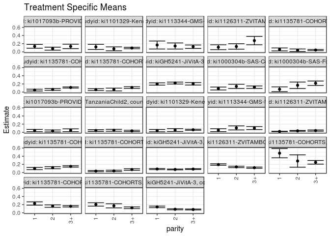

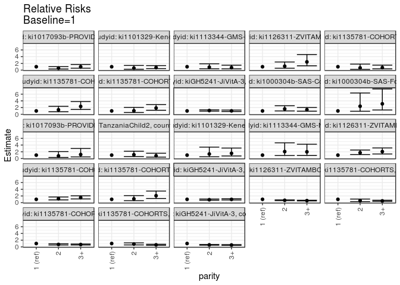

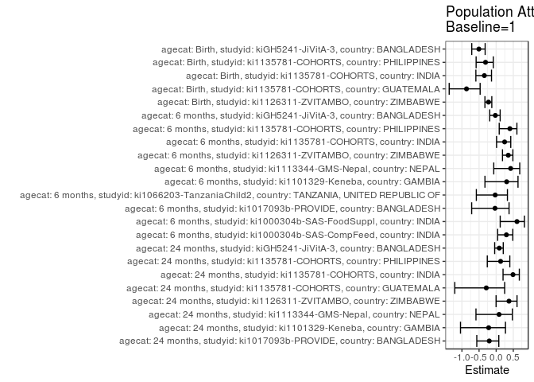

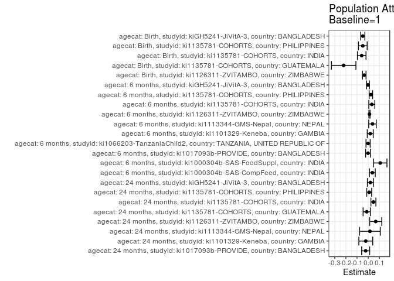

## Results Table

### Parameter: TSM

| agecat | studyid | country | intervention_level | baseline_level | estimate | ci_lower | ci_upper |
| --- | --- | --- | --- | --- | --- | --- | --- |
| Birth | ki1126311-ZVITAMBO | ZIMBABWE | 1 | NA | 0.1952151 | 0.1776556 | 0.2127746 |
| Birth | ki1126311-ZVITAMBO | ZIMBABWE | 2 | NA | 0.1384833 | 0.1214372 | 0.1555294 |
| Birth | ki1126311-ZVITAMBO | ZIMBABWE | 3+ | NA | 0.1187118 | 0.1024244 | 0.1349992 |
| Birth | ki1135781-COHORTS | GUATEMALA | 1 | NA | 0.4740188 | 0.3611249 | 0.5869127 |
| Birth | ki1135781-COHORTS | GUATEMALA | 2 | NA | 0.2824429 | 0.1313608 | 0.4335251 |
| Birth | ki1135781-COHORTS | GUATEMALA | 3+ | NA | 0.2510502 | 0.2071466 | 0.2949538 |
| Birth | ki1135781-COHORTS | INDIA | 1 | NA | 0.2271739 | 0.1866060 | 0.2677418 |
| Birth | ki1135781-COHORTS | INDIA | 2 | NA | 0.1643673 | 0.1342732 | 0.1944615 |
| Birth | ki1135781-COHORTS | INDIA | 3+ | NA | 0.1584520 | 0.1411087 | 0.1757953 |
| Birth | ki1135781-COHORTS | PHILIPPINES | 1 | NA | 0.2039939 | 0.1623488 | 0.2456389 |
| Birth | ki1135781-COHORTS | PHILIPPINES | 2 | NA | 0.1707948 | 0.1204379 | 0.2211517 |
| Birth | ki1135781-COHORTS | PHILIPPINES | 3+ | NA | 0.1226081 | 0.1011455 | 0.1440707 |
| Birth | kiGH5241-JiVitA-3 | BANGLADESH | 1 | NA | 0.1444451 | 0.1252815 | 0.1636087 |
| Birth | kiGH5241-JiVitA-3 | BANGLADESH | 2 | NA | 0.0860821 | 0.0733436 | 0.0988206 |
| Birth | kiGH5241-JiVitA-3 | BANGLADESH | 3+ | NA | 0.0802925 | 0.0692233 | 0.0913616 |
| 6 months | ki1000304b-SAS-CompFeed | INDIA | 1 | NA | 0.0872611 | 0.0509447 | 0.1235775 |
| 6 months | ki1000304b-SAS-CompFeed | INDIA | 2 | NA | 0.1396185 | 0.0883647 | 0.1908723 |
| 6 months | ki1000304b-SAS-CompFeed | INDIA | 3+ | NA | 0.1196359 | 0.0885710 | 0.1507008 |
| 6 months | ki1000304b-SAS-FoodSuppl | INDIA | 1 | NA | 0.0694444 | 0.0106475 | 0.1282414 |
| 6 months | ki1000304b-SAS-FoodSuppl | INDIA | 2 | NA | 0.1666667 | 0.0868626 | 0.2464708 |
| 6 months | ki1000304b-SAS-FoodSuppl | INDIA | 3+ | NA | 0.2165899 | 0.1617098 | 0.2714700 |
| 6 months | ki1017093b-PROVIDE | BANGLADESH | 1 | NA | 0.0426540 | 0.0153646 | 0.0699435 |
| 6 months | ki1017093b-PROVIDE | BANGLADESH | 2 | NA | 0.0330189 | 0.0089451 | 0.0570926 |
| 6 months | ki1017093b-PROVIDE | BANGLADESH | 3+ | NA | 0.0503145 | 0.0163082 | 0.0843208 |
| 6 months | ki1066203-TanzaniaChild2 | TANZANIA, UNITED REPUBLIC OF | 1 | NA | 0.0438831 | 0.0230995 | 0.0646667 |
| 6 months | ki1066203-TanzaniaChild2 | TANZANIA, UNITED REPUBLIC OF | 2 | NA | 0.0492729 | 0.0264273 | 0.0721185 |
| 6 months | ki1066203-TanzaniaChild2 | TANZANIA, UNITED REPUBLIC OF | 3+ | NA | 0.0352151 | 0.0186568 | 0.0517735 |
| 6 months | ki1101329-Keneba | GAMBIA | 1 | NA | 0.0410256 | 0.0131775 | 0.0688738 |
| 6 months | ki1101329-Keneba | GAMBIA | 2 | NA | 0.0548780 | 0.0200120 | 0.0897441 |
| 6 months | ki1101329-Keneba | GAMBIA | 3+ | NA | 0.0625000 | 0.0491515 | 0.0758485 |
| 6 months | ki1113344-GMS-Nepal | NEPAL | 1 | NA | 0.0522876 | 0.0169834 | 0.0875917 |
| 6 months | ki1113344-GMS-Nepal | NEPAL | 2 | NA | 0.1073826 | 0.0576271 | 0.1571380 |
| 6 months | ki1113344-GMS-Nepal | NEPAL | 3+ | NA | 0.1034483 | 0.0664686 | 0.1404280 |
| 6 months | ki1126311-ZVITAMBO | ZIMBABWE | 1 | NA | 0.0207268 | 0.0153212 | 0.0261324 |
| 6 months | ki1126311-ZVITAMBO | ZIMBABWE | 2 | NA | 0.0355174 | 0.0254267 | 0.0456080 |
| 6 months | ki1126311-ZVITAMBO | ZIMBABWE | 3+ | NA | 0.0424959 | 0.0281330 | 0.0568588 |
| 6 months | ki1135781-COHORTS | INDIA | 1 | NA | 0.0988048 | 0.0709239 | 0.1266858 |
| 6 months | ki1135781-COHORTS | INDIA | 2 | NA | 0.1175010 | 0.0919412 | 0.1430608 |
| 6 months | ki1135781-COHORTS | INDIA | 3+ | NA | 0.1500496 | 0.1338520 | 0.1662472 |
| 6 months | ki1135781-COHORTS | PHILIPPINES | 1 | NA | 0.0356704 | 0.0198243 | 0.0515165 |
| 6 months | ki1135781-COHORTS | PHILIPPINES | 2 | NA | 0.0401956 | 0.0226542 | 0.0577369 |
| 6 months | ki1135781-COHORTS | PHILIPPINES | 3+ | NA | 0.0739222 | 0.0548341 | 0.0930103 |
| 6 months | kiGH5241-JiVitA-3 | BANGLADESH | 1 | NA | 0.0866596 | 0.0730128 | 0.1003065 |
| 6 months | kiGH5241-JiVitA-3 | BANGLADESH | 2 | NA | 0.0756920 | 0.0654942 | 0.0858897 |
| 6 months | kiGH5241-JiVitA-3 | BANGLADESH | 3+ | NA | 0.0848714 | 0.0741708 | 0.0955721 |
| 24 months | ki1017093b-PROVIDE | BANGLADESH | 1 | NA | 0.1352117 | 0.0884240 | 0.1819994 |
| 24 months | ki1017093b-PROVIDE | BANGLADESH | 2 | NA | 0.0777613 | 0.0410329 | 0.1144896 |
| 24 months | ki1017093b-PROVIDE | BANGLADESH | 3+ | NA | 0.1326748 | 0.0784309 | 0.1869188 |
| 24 months | ki1101329-Keneba | GAMBIA | 1 | NA | 0.1213989 | 0.0586992 | 0.1840986 |
| 24 months | ki1101329-Keneba | GAMBIA | 2 | NA | 0.0733736 | 0.0255622 | 0.1211850 |
| 24 months | ki1101329-Keneba | GAMBIA | 3+ | NA | 0.0937074 | 0.0761285 | 0.1112864 |
| 24 months | ki1113344-GMS-Nepal | NEPAL | 1 | NA | 0.1672790 | 0.0699235 | 0.2646346 |
| 24 months | ki1113344-GMS-Nepal | NEPAL | 2 | NA | 0.1435261 | 0.0691437 | 0.2179085 |
| 24 months | ki1113344-GMS-Nepal | NEPAL | 3+ | NA | 0.1254576 | 0.0832091 | 0.1677060 |
| 24 months | ki1126311-ZVITAMBO | ZIMBABWE | 1 | NA | 0.1127545 | 0.0537374 | 0.1717717 |
| 24 months | ki1126311-ZVITAMBO | ZIMBABWE | 2 | NA | 0.1314620 | 0.0649968 | 0.1979273 |
| 24 months | ki1126311-ZVITAMBO | ZIMBABWE | 3+ | NA | 0.2752215 | 0.1725636 | 0.3778793 |
| 24 months | ki1135781-COHORTS | GUATEMALA | 1 | NA | 0.0598802 | 0.0238784 | 0.0958821 |
| 24 months | ki1135781-COHORTS | GUATEMALA | 2 | NA | 0.0397351 | 0.0085646 | 0.0709056 |
| 24 months | ki1135781-COHORTS | GUATEMALA | 3+ | NA | 0.0448549 | 0.0301129 | 0.0595968 |
| 24 months | ki1135781-COHORTS | INDIA | 1 | NA | 0.0480808 | 0.0257353 | 0.0704263 |
| 24 months | ki1135781-COHORTS | INDIA | 2 | NA | 0.0642356 | 0.0423745 | 0.0860968 |
| 24 months | ki1135781-COHORTS | INDIA | 3+ | NA | 0.1125357 | 0.0977606 | 0.1273107 |
| 24 months | ki1135781-COHORTS | PHILIPPINES | 1 | NA | 0.0593503 | 0.0358997 | 0.0828008 |
| 24 months | ki1135781-COHORTS | PHILIPPINES | 2 | NA | 0.0623439 | 0.0287279 | 0.0959599 |
| 24 months | ki1135781-COHORTS | PHILIPPINES | 3+ | NA | 0.1109432 | 0.0906686 | 0.1312178 |
| 24 months | kiGH5241-JiVitA-3 | BANGLADESH | 1 | NA | 0.1983667 | 0.1699809 | 0.2267526 |
| 24 months | kiGH5241-JiVitA-3 | BANGLADESH | 2 | NA | 0.2213958 | 0.1982364 | 0.2445553 |
| 24 months | kiGH5241-JiVitA-3 | BANGLADESH | 3+ | NA | 0.2032337 | 0.1720842 | 0.2343832 |

### Parameter: E(Y)

| agecat | studyid | country | intervention_level | baseline_level | estimate | ci_lower | ci_upper |
| --- | --- | --- | --- | --- | --- | --- | --- |
| Birth | ki1126311-ZVITAMBO | ZIMBABWE | NA | NA | 0.1595045 | 0.1531895 | 0.1658194 |
| Birth | ki1135781-COHORTS | GUATEMALA | NA | NA | 0.2539683 | 0.2229196 | 0.2850169 |
| Birth | ki1135781-COHORTS | INDIA | NA | NA | 0.1688716 | 0.1570438 | 0.1806994 |
| Birth | ki1135781-COHORTS | PHILIPPINES | NA | NA | 0.1555709 | 0.1423748 | 0.1687670 |
| Birth | kiGH5241-JiVitA-3 | BANGLADESH | NA | NA | 0.0959725 | 0.0907703 | 0.1011747 |
| 6 months | ki1000304b-SAS-CompFeed | INDIA | NA | NA | 0.1244378 | 0.0992652 | 0.1496104 |
| 6 months | ki1000304b-SAS-FoodSuppl | INDIA | NA | NA | 0.1769437 | 0.1381636 | 0.2157238 |
| 6 months | ki1017093b-PROVIDE | BANGLADESH | NA | NA | 0.0412371 | 0.0250690 | 0.0574052 |
| 6 months | ki1066203-TanzaniaChild2 | TANZANIA, UNITED REPUBLIC OF | NA | NA | 0.0426279 | 0.0337587 | 0.0514970 |
| 6 months | ki1101329-Keneba | GAMBIA | NA | NA | 0.0591497 | 0.0476693 | 0.0706302 |
| 6 months | ki1113344-GMS-Nepal | NEPAL | NA | NA | 0.0905861 | 0.0668565 | 0.1143158 |
| 6 months | ki1126311-ZVITAMBO | ZIMBABWE | NA | NA | 0.0320707 | 0.0282716 | 0.0358698 |
| 6 months | ki1135781-COHORTS | INDIA | NA | NA | 0.1311552 | 0.1210467 | 0.1412637 |
| 6 months | ki1135781-COHORTS | PHILIPPINES | NA | NA | 0.0594974 | 0.0505830 | 0.0684118 |
| 6 months | kiGH5241-JiVitA-3 | BANGLADESH | NA | NA | 0.0845851 | 0.0797798 | 0.0893904 |
| 24 months | ki1017093b-PROVIDE | BANGLADESH | NA | NA | 0.1124567 | 0.0866788 | 0.1382347 |
| 24 months | ki1101329-Keneba | GAMBIA | NA | NA | 0.0995640 | 0.0837378 | 0.1153901 |
| 24 months | ki1113344-GMS-Nepal | NEPAL | NA | NA | 0.1827309 | 0.1487560 | 0.2167058 |
| 24 months | ki1126311-ZVITAMBO | ZIMBABWE | NA | NA | 0.1800948 | 0.1433886 | 0.2168010 |
| 24 months | ki1135781-COHORTS | GUATEMALA | NA | NA | 0.0464684 | 0.0338852 | 0.0590516 |
| 24 months | ki1135781-COHORTS | INDIA | NA | NA | 0.0945140 | 0.0846121 | 0.1044160 |
| 24 months | ki1135781-COHORTS | PHILIPPINES | NA | NA | 0.0681911 | 0.0582056 | 0.0781766 |
| 24 months | kiGH5241-JiVitA-3 | BANGLADESH | NA | NA | 0.2180337 | 0.2081516 | 0.2279159 |

### Parameter: RR

| agecat | studyid | country | intervention_level | baseline_level | estimate | ci_lower | ci_upper |
| --- | --- | --- | --- | --- | --- | --- | --- |
| Birth | ki1126311-ZVITAMBO | ZIMBABWE | 1 | 1 | 1.0000000 | 1.0000000 | 1.0000000 |
| Birth | ki1126311-ZVITAMBO | ZIMBABWE | 2 | 1 | 0.7093882 | 0.6090665 | 0.8262343 |
| Birth | ki1126311-ZVITAMBO | ZIMBABWE | 3+ | 1 | 0.6081078 | 0.5161049 | 0.7165114 |
| Birth | ki1135781-COHORTS | GUATEMALA | 1 | 1 | 1.0000000 | 1.0000000 | 1.0000000 |
| Birth | ki1135781-COHORTS | GUATEMALA | 2 | 1 | 0.5958476 | 0.3319548 | 1.0695262 |
| Birth | ki1135781-COHORTS | GUATEMALA | 3+ | 1 | 0.5296207 | 0.3943887 | 0.7112226 |
| Birth | ki1135781-COHORTS | INDIA | 1 | 1 | 1.0000000 | 1.0000000 | 1.0000000 |
| Birth | ki1135781-COHORTS | INDIA | 2 | 1 | 0.7235309 | 0.5602256 | 0.9344395 |
| Birth | ki1135781-COHORTS | INDIA | 3+ | 1 | 0.6974920 | 0.5656910 | 0.8600016 |
| Birth | ki1135781-COHORTS | PHILIPPINES | 1 | 1 | 1.0000000 | 1.0000000 | 1.0000000 |
| Birth | ki1135781-COHORTS | PHILIPPINES | 2 | 1 | 0.8372546 | 0.5848637 | 1.1985619 |
| Birth | ki1135781-COHORTS | PHILIPPINES | 3+ | 1 | 0.6010383 | 0.4593113 | 0.7864972 |
| Birth | kiGH5241-JiVitA-3 | BANGLADESH | 1 | 1 | 1.0000000 | 1.0000000 | 1.0000000 |
| Birth | kiGH5241-JiVitA-3 | BANGLADESH | 2 | 1 | 0.5959503 | 0.4887850 | 0.7266113 |
| Birth | kiGH5241-JiVitA-3 | BANGLADESH | 3+ | 1 | 0.5558684 | 0.4578532 | 0.6748663 |
| 6 months | ki1000304b-SAS-CompFeed | INDIA | 1 | 1 | 1.0000000 | 1.0000000 | 1.0000000 |
| 6 months | ki1000304b-SAS-CompFeed | INDIA | 2 | 1 | 1.6000079 | 1.0023412 | 2.5540457 |
| 6 months | ki1000304b-SAS-CompFeed | INDIA | 3+ | 1 | 1.3710104 | 0.9273774 | 2.0268658 |
| 6 months | ki1000304b-SAS-FoodSuppl | INDIA | 1 | 1 | 1.0000000 | 1.0000000 | 1.0000000 |
| 6 months | ki1000304b-SAS-FoodSuppl | INDIA | 2 | 1 | 2.4000000 | 0.9073519 | 6.3481435 |
| 6 months | ki1000304b-SAS-FoodSuppl | INDIA | 3+ | 1 | 3.1188940 | 1.2887863 | 7.5477991 |
| 6 months | ki1017093b-PROVIDE | BANGLADESH | 1 | 1 | 1.0000000 | 1.0000000 | 1.0000000 |
| 6 months | ki1017093b-PROVIDE | BANGLADESH | 2 | 1 | 0.7741090 | 0.2934517 | 2.0420557 |
| 6 months | ki1017093b-PROVIDE | BANGLADESH | 3+ | 1 | 1.1795947 | 0.4651051 | 2.9916758 |
| 6 months | ki1066203-TanzaniaChild2 | TANZANIA, UNITED REPUBLIC OF | 1 | 1 | 1.0000000 | 1.0000000 | 1.0000000 |
| 6 months | ki1066203-TanzaniaChild2 | TANZANIA, UNITED REPUBLIC OF | 2 | 1 | 1.1228213 | 0.5789119 | 2.1777539 |
| 6 months | ki1066203-TanzaniaChild2 | TANZANIA, UNITED REPUBLIC OF | 3+ | 1 | 0.8024758 | 0.4117079 | 1.5641367 |
| 6 months | ki1101329-Keneba | GAMBIA | 1 | 1 | 1.0000000 | 1.0000000 | 1.0000000 |
| 6 months | ki1101329-Keneba | GAMBIA | 2 | 1 | 1.3376523 | 0.5279118 | 3.3894177 |
| 6 months | ki1101329-Keneba | GAMBIA | 3+ | 1 | 1.5234373 | 0.7477881 | 3.1036350 |
| 6 months | ki1113344-GMS-Nepal | NEPAL | 1 | 1 | 1.0000000 | 1.0000000 | 1.0000000 |
| 6 months | ki1113344-GMS-Nepal | NEPAL | 2 | 1 | 2.0536913 | 0.9055182 | 4.6577174 |
| 6 months | ki1113344-GMS-Nepal | NEPAL | 3+ | 1 | 1.9784483 | 0.9215762 | 4.2473510 |
| 6 months | ki1126311-ZVITAMBO | ZIMBABWE | 1 | 1 | 1.0000000 | 1.0000000 | 1.0000000 |
| 6 months | ki1126311-ZVITAMBO | ZIMBABWE | 2 | 1 | 1.7135942 | 1.1650378 | 2.5204376 |
| 6 months | ki1126311-ZVITAMBO | ZIMBABWE | 3+ | 1 | 2.0502845 | 1.3379480 | 3.1418759 |
| 6 months | ki1135781-COHORTS | INDIA | 1 | 1 | 1.0000000 | 1.0000000 | 1.0000000 |
| 6 months | ki1135781-COHORTS | INDIA | 2 | 1 | 1.1892229 | 0.8326885 | 1.6984156 |
| 6 months | ki1135781-COHORTS | INDIA | 3+ | 1 | 1.5186464 | 1.1226224 | 2.0543746 |
| 6 months | ki1135781-COHORTS | PHILIPPINES | 1 | 1 | 1.0000000 | 1.0000000 | 1.0000000 |
| 6 months | ki1135781-COHORTS | PHILIPPINES | 2 | 1 | 1.1268609 | 0.6048711 | 2.0993159 |
| 6 months | ki1135781-COHORTS | PHILIPPINES | 3+ | 1 | 2.0723695 | 1.2396982 | 3.4643230 |
| 6 months | kiGH5241-JiVitA-3 | BANGLADESH | 1 | 1 | 1.0000000 | 1.0000000 | 1.0000000 |
| 6 months | kiGH5241-JiVitA-3 | BANGLADESH | 2 | 1 | 0.8734399 | 0.7072404 | 1.0786958 |
| 6 months | kiGH5241-JiVitA-3 | BANGLADESH | 3+ | 1 | 0.9793655 | 0.8046225 | 1.1920580 |
| 24 months | ki1017093b-PROVIDE | BANGLADESH | 1 | 1 | 1.0000000 | 1.0000000 | 1.0000000 |
| 24 months | ki1017093b-PROVIDE | BANGLADESH | 2 | 1 | 0.5751077 | 0.3200953 | 1.0332826 |
| 24 months | ki1017093b-PROVIDE | BANGLADESH | 3+ | 1 | 0.9812381 | 0.5742837 | 1.6765724 |
| 24 months | ki1101329-Keneba | GAMBIA | 1 | 1 | 1.0000000 | 1.0000000 | 1.0000000 |
| 24 months | ki1101329-Keneba | GAMBIA | 2 | 1 | 0.6044008 | 0.2630880 | 1.3885100 |
| 24 months | ki1101329-Keneba | GAMBIA | 3+ | 1 | 0.7718968 | 0.4456080 | 1.3371047 |
| 24 months | ki1113344-GMS-Nepal | NEPAL | 1 | 1 | 1.0000000 | 1.0000000 | 1.0000000 |
| 24 months | ki1113344-GMS-Nepal | NEPAL | 2 | 1 | 0.8580043 | 0.3944944 | 1.8661137 |
| 24 months | ki1113344-GMS-Nepal | NEPAL | 3+ | 1 | 0.7499900 | 0.3818236 | 1.4731542 |
| 24 months | ki1126311-ZVITAMBO | ZIMBABWE | 1 | 1 | 1.0000000 | 1.0000000 | 1.0000000 |
| 24 months | ki1126311-ZVITAMBO | ZIMBABWE | 2 | 1 | 1.1659133 | 0.5644451 | 2.4083009 |
| 24 months | ki1126311-ZVITAMBO | ZIMBABWE | 3+ | 1 | 2.4408903 | 1.2863449 | 4.6316859 |
| 24 months | ki1135781-COHORTS | GUATEMALA | 1 | 1 | 1.0000000 | 1.0000000 | 1.0000000 |
| 24 months | ki1135781-COHORTS | GUATEMALA | 2 | 1 | 0.6635762 | 0.2469743 | 1.7829113 |
| 24 months | ki1135781-COHORTS | GUATEMALA | 3+ | 1 | 0.7490765 | 0.3775276 | 1.4862905 |
| 24 months | ki1135781-COHORTS | INDIA | 1 | 1 | 1.0000000 | 1.0000000 | 1.0000000 |
| 24 months | ki1135781-COHORTS | INDIA | 2 | 1 | 1.3359933 | 0.7511544 | 2.3761801 |
| 24 months | ki1135781-COHORTS | INDIA | 3+ | 1 | 2.3405540 | 1.4439131 | 3.7939908 |
| 24 months | ki1135781-COHORTS | PHILIPPINES | 1 | 1 | 1.0000000 | 1.0000000 | 1.0000000 |
| 24 months | ki1135781-COHORTS | PHILIPPINES | 2 | 1 | 1.0504399 | 0.5383784 | 2.0495321 |
| 24 months | ki1135781-COHORTS | PHILIPPINES | 3+ | 1 | 1.8692959 | 1.2093418 | 2.8893957 |
| 24 months | kiGH5241-JiVitA-3 | BANGLADESH | 1 | 1 | 1.0000000 | 1.0000000 | 1.0000000 |
| 24 months | kiGH5241-JiVitA-3 | BANGLADESH | 2 | 1 | 1.1160935 | 0.9326541 | 1.3356128 |
| 24 months | kiGH5241-JiVitA-3 | BANGLADESH | 3+ | 1 | 1.0245354 | 0.8305503 | 1.2638279 |

### Parameter: PAR

| agecat | studyid | country | intervention_level | baseline_level | estimate | ci_lower | ci_upper |
| --- | --- | --- | --- | --- | --- | --- | --- |
| Birth | ki1126311-ZVITAMBO | ZIMBABWE | 1 | NA | -0.0357107 | -0.0517368 | -0.0196845 |
| Birth | ki1135781-COHORTS | GUATEMALA | 1 | NA | -0.2200505 | -0.3296279 | -0.1104732 |
| Birth | ki1135781-COHORTS | INDIA | 1 | NA | -0.0583023 | -0.0966299 | -0.0199747 |
| Birth | ki1135781-COHORTS | PHILIPPINES | 1 | NA | -0.0484230 | -0.0871938 | -0.0096521 |
| Birth | kiGH5241-JiVitA-3 | BANGLADESH | 1 | NA | -0.0484726 | -0.0669773 | -0.0299679 |
| 6 months | ki1000304b-SAS-CompFeed | INDIA | 1 | NA | 0.0371767 | 0.0112745 | 0.0630788 |
| 6 months | ki1000304b-SAS-FoodSuppl | INDIA | 1 | NA | 0.1074993 | 0.0472802 | 0.1677183 |
| 6 months | ki1017093b-PROVIDE | BANGLADESH | 1 | NA | -0.0014169 | -0.0230072 | 0.0201734 |
| 6 months | ki1066203-TanzaniaChild2 | TANZANIA, UNITED REPUBLIC OF | 1 | NA | -0.0012552 | -0.0200257 | 0.0175153 |
| 6 months | ki1101329-Keneba | GAMBIA | 1 | NA | 0.0181241 | -0.0087267 | 0.0449749 |
| 6 months | ki1113344-GMS-Nepal | NEPAL | 1 | NA | 0.0382986 | 0.0046526 | 0.0719445 |
| 6 months | ki1126311-ZVITAMBO | ZIMBABWE | 1 | NA | 0.0113439 | 0.0063478 | 0.0163399 |
| 6 months | ki1135781-COHORTS | INDIA | 1 | NA | 0.0323504 | 0.0053978 | 0.0593030 |
| 6 months | ki1135781-COHORTS | PHILIPPINES | 1 | NA | 0.0238270 | 0.0084731 | 0.0391810 |
| 6 months | kiGH5241-JiVitA-3 | BANGLADESH | 1 | NA | -0.0020745 | -0.0149006 | 0.0107516 |
| 24 months | ki1017093b-PROVIDE | BANGLADESH | 1 | NA | -0.0227549 | -0.0587426 | 0.0132328 |
| 24 months | ki1101329-Keneba | GAMBIA | 1 | NA | -0.0218350 | -0.0840113 | 0.0403414 |
| 24 months | ki1113344-GMS-Nepal | NEPAL | 1 | NA | 0.0154519 | -0.0769794 | 0.1078832 |
| 24 months | ki1126311-ZVITAMBO | ZIMBABWE | 1 | NA | 0.0673402 | 0.0132638 | 0.1214166 |
| 24 months | ki1135781-COHORTS | GUATEMALA | 1 | NA | -0.0134118 | -0.0458485 | 0.0190249 |
| 24 months | ki1135781-COHORTS | INDIA | 1 | NA | 0.0464332 | 0.0242229 | 0.0686436 |
| 24 months | ki1135781-COHORTS | PHILIPPINES | 1 | NA | 0.0088408 | -0.0131443 | 0.0308260 |
| 24 months | kiGH5241-JiVitA-3 | BANGLADESH | 1 | NA | 0.0196670 | -0.0075899 | 0.0469239 |

### Parameter: PAF

| agecat | studyid | country | intervention_level | baseline_level | estimate | ci_lower | ci_upper |
| --- | --- | --- | --- | --- | --- | --- | --- |
| Birth | ki1126311-ZVITAMBO | ZIMBABWE | 1 | NA | -0.2238850 | -0.3284708 | -0.1275329 |
| Birth | ki1135781-COHORTS | GUATEMALA | 1 | NA | -0.8664490 | -1.3723811 | -0.4684116 |
| Birth | ki1135781-COHORTS | INDIA | 1 | NA | -0.3452463 | -0.5928403 | -0.1361388 |
| Birth | ki1135781-COHORTS | PHILIPPINES | 1 | NA | -0.3112599 | -0.5856469 | -0.0843539 |
| Birth | kiGH5241-JiVitA-3 | BANGLADESH | 1 | NA | -0.5050682 | -0.7133350 | -0.3221175 |
| 6 months | ki1000304b-SAS-CompFeed | INDIA | 1 | NA | 0.2987570 | 0.0439082 | 0.4856752 |
| 6 months | ki1000304b-SAS-FoodSuppl | INDIA | 1 | NA | 0.6075337 | 0.1176744 | 0.8254275 |
| 6 months | ki1017093b-PROVIDE | BANGLADESH | 1 | NA | -0.0343602 | -0.7156685 | 0.3763941 |
| 6 months | ki1066203-TanzaniaChild2 | TANZANIA, UNITED REPUBLIC OF | 1 | NA | -0.0294461 | -0.5789869 | 0.3288360 |
| 6 months | ki1101329-Keneba | GAMBIA | 1 | NA | 0.3064102 | -0.3277241 | 0.6376756 |
| 6 months | ki1113344-GMS-Nepal | NEPAL | 1 | NA | 0.4227861 | -0.0704734 | 0.6887584 |
| 6 months | ki1126311-ZVITAMBO | ZIMBABWE | 1 | NA | 0.3537141 | 0.1847715 | 0.4876462 |
| 6 months | ki1135781-COHORTS | INDIA | 1 | NA | 0.2466571 | 0.0115911 | 0.4258191 |
| 6 months | ki1135781-COHORTS | PHILIPPINES | 1 | NA | 0.4004717 | 0.0889370 | 0.6054782 |
| 6 months | kiGH5241-JiVitA-3 | BANGLADESH | 1 | NA | -0.0245257 | -0.1879829 | 0.1164411 |
| 24 months | ki1017093b-PROVIDE | BANGLADESH | 1 | NA | -0.2023436 | -0.5658806 | 0.0767941 |
| 24 months | ki1101329-Keneba | GAMBIA | 1 | NA | -0.2193061 | -1.0419854 | 0.2719305 |
| 24 months | ki1113344-GMS-Nepal | NEPAL | 1 | NA | 0.0845610 | -0.5902193 | 0.4730107 |
| 24 months | ki1126311-ZVITAMBO | ZIMBABWE | 1 | NA | 0.3739156 | -0.0025141 | 0.6090013 |
| 24 months | ki1135781-COHORTS | GUATEMALA | 1 | NA | -0.2886228 | -1.2084474 | 0.2480923 |
| 24 months | ki1135781-COHORTS | INDIA | 1 | NA | 0.4912840 | 0.2007868 | 0.6761916 |
| 24 months | ki1135781-COHORTS | PHILIPPINES | 1 | NA | 0.1296480 | -0.2593157 | 0.3984729 |
| 24 months | kiGH5241-JiVitA-3 | BANGLADESH | 1 | NA | 0.0902016 | -0.0435800 | 0.2068332 |